# Hate crimes in NYC

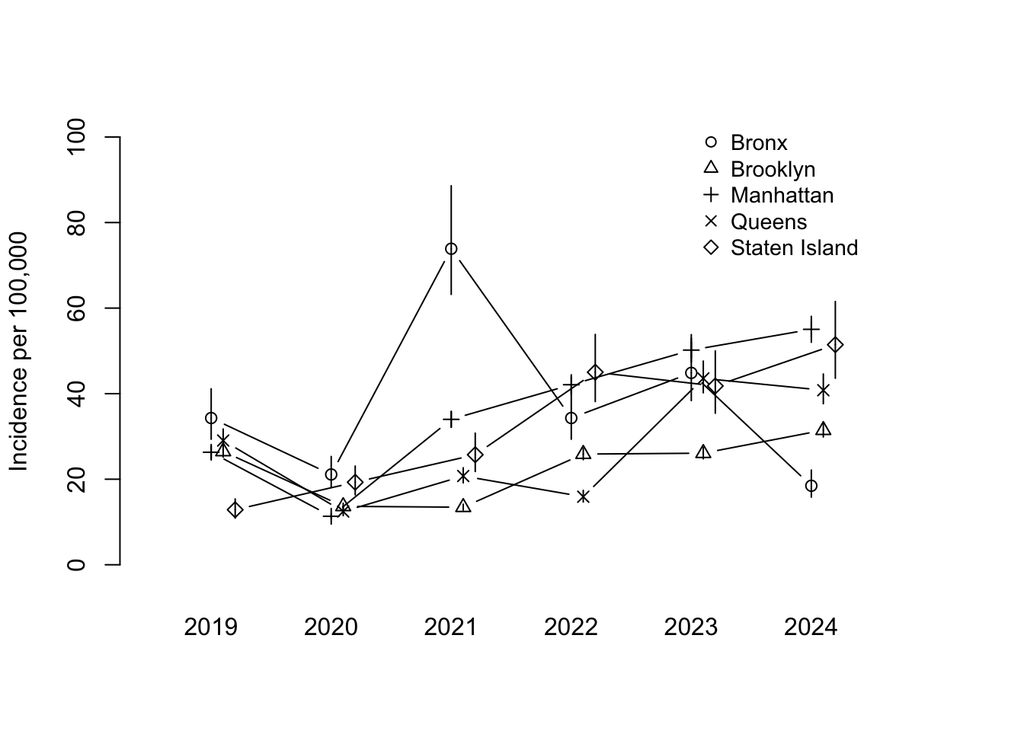

```r
plotCI(incidence[1,], li=incidence.lo[1,], ui=incidence.hi[1,], xlim=c(2018.5, 2025), ylim=c(0, 100), x=0+2019:2024, pch=1, axes=F, lty=1, sfrac=0, gap=0, ylab="Incidence per 100,000", xlab="", type="b")
par(new=T)
plotCI(incidence[2,], li=incidence.lo[2,], ui=incidence.hi[2,], xlim=c(2018.5, 2025), ylim=c(0, 100), x=0.1+2019:2024, pch=2, axes=F, lty=1, sfrac=0, gap=0, ylab="", xlab="", type="b")
par(new=T)
plotCI(incidence[3,], li=incidence.lo[3,], ui=incidence.hi[3,], xlim=c(2018.5, 2025), ylim=c(0, 100), x=0+2019:2024, pch=3, axes=F, lty=1, sfrac=0, gap=0, ylab="", xlab="", type="b")
par(new=T)
plotCI(incidence[4,], li=incidence.lo[4,], ui=incidence.hi[4,], xlim=c(2018.5, 2025), ylim=c(0, 100), x=0.1+2019:2024, pch=4, axes=F, lty=1, sfrac=0, gap=0, ylab="", xlab="", type="b")
par(new=T)
plotCI(incidence[5,], li=incidence.lo[5,], ui=incidence.hi[5,], xlim=c(2018.5, 2025), ylim=c(0, 100), x=0.2+2019:2024, pch=5, axes=F, lty=1, sfrac=0, gap=0, ylab="", xlab="", type="b")
par(new=T)
axis(side=2)
axis(side=1, at=2019:2024, lwd=0, lwd.ticks=0)
legend(2023, 105, rownames(incidence), ncol=1, bty="n", cex=0.9, pch=1:5)
```

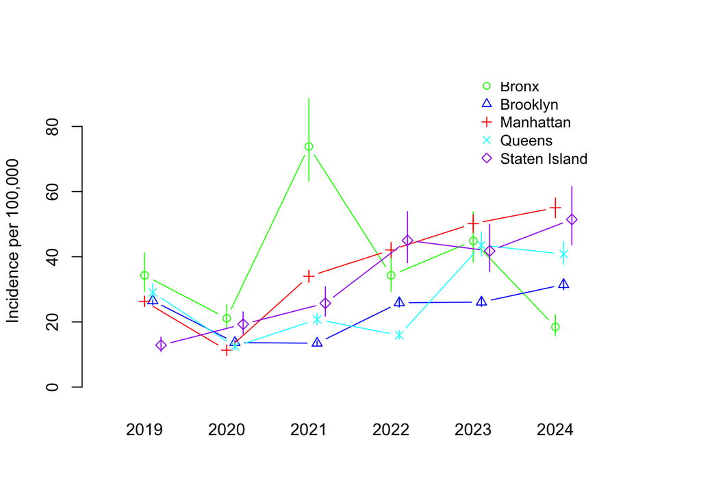

```r
plotCI(incidence[1,], li=incidence.lo[1,], ui=incidence.hi[1,], xlim=c(2018.5, 2025), ylim=c(0, 90), x=0+2019:2024, pch=1, axes=F, lty=1, sfrac=0, gap=0, ylab="Incidence per 100,000", xlab="", col="green", barcol="green", type="b")
par(new=T)
plotCI(incidence[2,], li=incidence.lo[2,], ui=incidence.hi[2,], xlim=c(2018.5, 2025), ylim=c(0, 90), x=0.1+2019:2024, pch=2, axes=F, lty=1, sfrac=0, gap=0, ylab="", xlab="", col="blue", barcol="blue", type="b")
par(new=T)
plotCI(incidence[3,], li=incidence.lo[3,], ui=incidence.hi[3,], xlim=c(2018.5, 2025), ylim=c(0, 90), x=0+2019:2024, pch=3, axes=F, lty=1, sfrac=0, gap=0, ylab="", xlab="", col="red", barcol="red", type="b")
par(new=T)
plotCI(incidence[4,], li=incidence.lo[4,], ui=incidence.hi[4,], xlim=c(2018.5, 2025), ylim=c(0, 90), x=0.1+2019:2024, pch=4, axes=F, lty=1, sfrac=0, gap=0, ylab="", xlab="", col="cyan", barcol="cyan", type="b")
par(new=T)
plotCI(incidence[5,], li=incidence.lo[5,], ui=incidence.hi[5,], xlim=c(2018.5, 2025), ylim=c(0, 90), x=0.2+2019:2024, pch=5, axes=F, lty=1, sfrac=0, gap=0, ylab="", xlab="", col="purple", barcol="purple", type="b")
par(new=T)
axis(side=2)
axis(side=1, at=2019:2024, lwd=0, lwd.ticks=0)
legend(2023, 98, rownames(incidence), col=c("green", "blue", "red", "cyan", "purple"), ncol=1, bty="n", cex=0.9, pch=1:5)
```

```r
tally(county~antijewish, data=H)
```

```
##           antijewish
## county     TRUE FALSE
##   BRONX      86   119
##   KINGS     662   534
##   NEW YORK  541   751
##   QUEENS    235   395
##   RICHMOND   61    66
```

```r
chisq.test(tally(county~antijewish, data=H))
```

```
##
##  Pearson's Chi-squared test
##
## data:  tally(county ~ antijewish, data = H)
## X-squared = 71.724, df = 4, p-value = 9.816e-15
```

```r
tally(county~antijewish, data=H, format="percent")
```

```
##           antijewish
## county          TRUE     FALSE
##   BRONX     5.425868  6.380697
##   KINGS    41.766562 28.632708
##   NEW YORK 34.132492 40.268097
##   QUEENS   14.826498 21.179625
##   RICHMOND  3.848580  3.538874
```

```r
pairwise.prop.test(tally(county~antijewish, data=H))
```

```
##
##  Pairwise comparisons using Pairwise comparison of proportions
##
## data:  tally(county ~ antijewish, data = H)
##
##          BRONX KINGS   NEW YORK QUEENS
## KINGS    0.004 -       -        -
## NEW YORK 1.000 2.1e-10 -        -
## QUEENS   0.851 3.2e-12 0.371    -
## RICHMOND 0.851 0.692   0.851    0.215
##
## P value adjustment method: holm
```

## Felonies

```r
tally(offensedescription~antijewish, data=H, subset=lawcodecategorydescription=="FELONY")
```

```
##                                 antijewish
## offensedescription               TRUE FALSE
##   ARSON                             2     1
##   BURGLARY                          6     8
##   CRIMINAL MISCHIEF & RELATED OF  101   110
##   DANGEROUS DRUGS                   1     0
##   DANGEROUS WEAPONS                 1     4
##   FELONY ASSAULT                   87   330
##   GRAND LARCENY                    34    13
##   HOMICIDE-NEGLIGENT,UNCLASSIFIE    0     2
##   KIDNAPPING & RELATED OFFENSES     0     1
##   MISCELLANEOUS PENAL LAW         750   138
##   MURDER & NON-NEGL. MANSLAUGHTE    0     8
##   RAPE                              0     1
##   ROBBERY                          21    94
##   SEX CRIMES                        1     2
```

```r
chisq.test(tally(offensedescription~antijewish, data=H, subset=lawcodecategorydescription=="FELONY"))
```

```
##
##  Pearson's Chi-squared test
##
## data:  tally(offensedescription ~ antijewish, data = H, subset = lawcodecategorydescription ==     "FELONY")
## X-squared = 603.02, df = 13, p-value < 2.2e-16
```

```r
tally(offensedescription~antijewish, data=H, subset=lawcodecategorydescription=="FELONY", format="percent")
```

```
##                                 antijewish
## offensedescription                      TRUE       FALSE
##   ARSON                           0.19920319  0.14044944
##   BURGLARY                        0.59760956  1.12359551
##   CRIMINAL MISCHIEF & RELATED OF 10.05976096 15.44943820
##   DANGEROUS DRUGS                 0.09960159  0.00000000
##   DANGEROUS WEAPONS               0.09960159  0.56179775
##   FELONY ASSAULT                  8.66533865 46.34831461
##   GRAND LARCENY                   3.38645418  1.82584270
##   HOMICIDE-NEGLIGENT,UNCLASSIFIE  0.00000000  0.28089888
##   KIDNAPPING & RELATED OFFENSES   0.00000000  0.14044944
##   MISCELLANEOUS PENAL LAW        74.70119522 19.38202247
##   MURDER & NON-NEGL. MANSLAUGHTE  0.00000000  1.12359551
##   RAPE                            0.00000000  0.14044944
##   ROBBERY                         2.09163347 13.20224719
##   SEX CRIMES                      0.09960159  0.28089888
```

```r
length(tally(~offensedescription, data=H))
```

```
## [1] 23
```

```r
tally(offensedescription ~ lawcodecategorydescription, data=H)
```

```
##                                 lawcodecategorydescription
## offensedescription               FELONY INVESTIGATION MISDEMEANOR VIOLATION
##   ARSON                               3             0           0         0
##   ASSAULT 3 & RELATED OFFENSES        0             0         705         0
##   BURGLARY                           14             0           0         0
##   CRIMINAL MISCHIEF & RELATED OF    211             0         484         0
##   CRIMINAL TRESPASS                   0             0           2         0
##   DANGEROUS DRUGS                     1             0           0         0
##   DANGEROUS WEAPONS                   5             0           0         0
##   FELONY ASSAULT                    417             0           0         0
##   FRAUDS                              0             0           1         0
##   GRAND LARCENY                      47             0           0         0
##   HARRASSMENT 2                       0             0           0        23
##   HOMICIDE-NEGLIGENT,UNCLASSIFIE      2             0           0         0
##   INVESTIGATIONS/COMPLAINTS ONLY      0             2           0         0
##   KIDNAPPING & RELATED OFFENSES       1             0           0         0
##   MISCELLANEOUS PENAL LAW           888             0           0         0
##   MURDER & NON-NEGL. MANSLAUGHTE      8             0           0         0
##   OFF. AGNST PUB ORD SENSBLTY &       0             0         477         0
##   OFFENSES AGAINST PUBLIC ADMINI      0             0           2         0
##   OFFENSES AGAINST THE PERSON         0             0           4         0
##   PETIT LARCENY                       0             0          22         0
##   RAPE                                1             0           0         0
##   ROBBERY                           115             0           0         0
##   SEX CRIMES                          3             0          12         0
```

```r
tally(noarrest~antijewish, data=H)
```

```
##         antijewish
## noarrest TRUE FALSE
##    TRUE  1118   810
##    FALSE  467  1055
```

```r
tally(noarrest~antijewish, data=H, format="percent")
```

```
##         antijewish
## noarrest     TRUE    FALSE
##    TRUE  70.53628 43.43164
##    FALSE 29.46372 56.56836
```

```r
chisq.test(tally(noarrest~antijewish, data=H))
```

```
##
##  Pearson's Chi-squared test with Yates' continuity correction
##
## data:  tally(noarrest ~ antijewish, data = H)
## X-squared = 254.23, df = 1, p-value < 2.2e-16
```

```r
tally(felony~antijewish, data=H)
```

```
##        antijewish
## felony  TRUE FALSE
##   TRUE  1004   712
##   FALSE  581  1153
```

```r
tally(felony~antijewish, data=H, format="percent")
```

```
##        antijewish
## felony      TRUE    FALSE
##   TRUE  63.34385 38.17694
##   FALSE 36.65615 61.82306
```

```r
chisq.test(tally(felony~antijewish, data=H))
```

```
##
##  Pearson's Chi-squared test with Yates' continuity correction
##
## data:  tally(felony ~ antijewish, data = H)
## X-squared = 216.07, df = 1, p-value < 2.2e-16
```

```r
tally(noarrest ~felony, data=H)
```

```
##         felony
## noarrest TRUE FALSE
##    TRUE   977   951
##    FALSE  739   783
```

```r
tally(noarrest ~felony, data=H, format="percent")
```

```
##         felony
## noarrest     TRUE    FALSE
##    TRUE  56.93473 54.84429
##    FALSE 43.06527 45.15571
```

```r
chisq.test(tally(noarrest ~felony, data=H))
```

```
##
##  Pearson's Chi-squared test with Yates' continuity correction
##
## data:  tally(noarrest ~ felony, data = H)
## X-squared = 1.4451, df = 1, p-value = 0.2293
```

```r
tally(noarrest ~felony, data=H, subset=antijewish==T)
```

```
##         felony
## noarrest TRUE FALSE
##    TRUE   719   399
##    FALSE  285   182
```

```r
tally(noarrest ~felony, data=H, format="percent", subset=antijewish==T)
```

```
##         felony
## noarrest     TRUE    FALSE
##    TRUE  71.61355 68.67470
##    FALSE 28.38645 31.32530
```

```r
chisq.test(tally(noarrest ~felony, data=H, subset=antijewish==T))
```

```
##
##  Pearson's Chi-squared test with Yates' continuity correction
##
## data:  tally(noarrest ~ felony, data = H, subset = antijewish == T)
## X-squared = 1.3913, df = 1, p-value = 0.2382
```

```r
tally(noarrest ~felony, data=H, subset=antijewish==F)
```

```
##         felony
## noarrest TRUE FALSE
##    TRUE   258   552
##    FALSE  454   601
```

```r
tally(noarrest ~felony, data=H, format="percent", subset=antijewish==F)
```

```
##         felony
## noarrest     TRUE    FALSE
##    TRUE  36.23596 47.87511
##    FALSE 63.76404 52.12489
```

```r
chisq.test(tally(noarrest ~felony, data=H, subset=antijewish==F))
```

```
##
##  Pearson's Chi-squared test with Yates' continuity correction
##
## data:  tally(noarrest ~ felony, data = H, subset = antijewish == F)
## X-squared = 23.8, df = 1, p-value = 1.069e-06
```

```r
H$misc=H$offensedescription=="MISCELLANEOUS PENAL LAW"
#tally(offensedescription ~ misc, data=H)
chisq.test(tally(misc~ antijewish, data=H))
```

```
##
##  Pearson's Chi-squared test with Yates' continuity correction
##
## data:  tally(misc ~ antijewish, data = H)
## X-squared = 712.24, df = 1, p-value < 2.2e-16
```

```r
tally(misc ~ antijewish, data=H, subset=noarrest==T & lawcodecategorydescription=="FELONY")
```

```
##        antijewish
## misc    TRUE FALSE
##   TRUE   601    81
##   FALSE  118   177
```

```r
tally(misc ~ antijewish, data=H, subset=noarrest==F & lawcodecategorydescription=="FELONY")
```

```
##        antijewish
## misc    TRUE FALSE
##   TRUE   149    57
##   FALSE  136   397
```

```r
tally(noarrest ~ misc, data=H, subset=antijewish==T & lawcodecategorydescription=="FELONY")
```

```
##         misc
## noarrest TRUE FALSE
##    TRUE   601   118
##    FALSE  149   136
```

```r
tally(noarrest ~ misc, data=H, subset=antijewish==F & lawcodecategorydescription=="FELONY")
```

```
##         misc
## noarrest TRUE FALSE
##    TRUE    81   177
##    FALSE   57   397
```

```r
tally(noarrest ~ misc, data=H, subset=antijewish==T & lawcodecategorydescription=="FELONY", format="percent")
```

```
##         misc
## noarrest     TRUE    FALSE
##    TRUE  80.13333 46.45669
##    FALSE 19.86667 53.54331
```

```r
tally(noarrest ~ misc, data=H, subset=antijewish==F & lawcodecategorydescription=="FELONY", format="percent")
```

```
##         misc
## noarrest     TRUE    FALSE
##    TRUE  58.69565 30.83624
##    FALSE 41.30435 69.16376
```

```r
chisq.test(tally(noarrest ~ misc, data=H, subset=antijewish==T & lawcodecategorydescription=="FELONY"))
```

```
##
##  Pearson's Chi-squared test with Yates' continuity correction
##
## data:  tally(noarrest ~ misc, data = H, subset = antijewish == T & lawcodecategorydescription ==     "FELONY")
## X-squared = 104.21, df = 1, p-value < 2.2e-16
```

```r
chisq.test(tally(noarrest ~ misc, data=H, subset=antijewish==F & lawcodecategorydescription=="FELONY"))
```

```
##
##  Pearson's Chi-squared test with Yates' continuity correction
##
## data:  tally(noarrest ~ misc, data = H, subset = antijewish == F & lawcodecategorydescription ==     "FELONY")
## X-squared = 36.175, df = 1, p-value = 1.803e-09
```

```r
H$crimmischief=H$offensedescription=="CRIMINAL MISCHIEF & RELATED OF" & H$lawcodecategorydescription=="FELONY"
#tally(offensedescription ~ crimmischief, data=H)
chisq.test(tally(crimmischief~ antijewish, data=H, subset= H$lawcodecategorydescription=="FELONY"))
```

```
##
##  Pearson's Chi-squared test with Yates' continuity correction
##
## data:  tally(crimmischief ~ antijewish, data = H, subset = H$lawcodecategorydescription ==     "FELONY")
## X-squared = 10.727, df = 1, p-value = 0.001056
```

```r
H$robbery=H$offensedescription=="ROBBERY"
#tally(offensedescription ~ robbery, data=H)
chisq.test(tally(robbery~ antijewish, data=H))
```

```
##
##  Pearson's Chi-squared test with Yates' continuity correction
##
## data:  tally(robbery ~ antijewish, data = H)
## X-squared = 35.561, df = 1, p-value = 2.472e-09
```

```r
H$miscpenal=H$offensedescription=="MISCELLANEOUS PENAL LAW"
#tally(offensedescription ~ miscpenal, data=H)
chisq.test(tally(miscpenal~ antijewish, data=H))
```

```
##
##  Pearson's Chi-squared test with Yates' continuity correction
##
## data:  tally(miscpenal ~ antijewish, data = H)
## X-squared = 712.24, df = 1, p-value < 2.2e-16
```

```r
H$grandlarceny=H$offensedescription=="GRAND LARCENY"
#tally(offensedescription ~ grandlarceny, data=H)
chisq.test(tally(grandlarceny~ antijewish, data=H))
```

```
##
##  Pearson's Chi-squared test with Yates' continuity correction
##
## data:  tally(grandlarceny ~ antijewish, data = H)
## X-squared = 12.314, df = 1, p-value = 0.0004495
```

```r
H$felonyassault=H$offensedescription=="FELONY ASSAULT"
#tally(offensedescription ~ felonyassault, data=H)
chisq.test(tally(felonyassault~ antijewish, data=H))
```

```
##
##  Pearson's Chi-squared test with Yates' continuity correction
##
## data:  tally(felonyassault ~ antijewish, data = H)
## X-squared = 118.98, df = 1, p-value < 2.2e-16
```

## misdemeanor

```r
tally(offensedescription~antijewish, data=H, subset=lawcodecategorydescription=="MISDEMEANOR")
```

```
##                                 antijewish
## offensedescription               TRUE FALSE
##   ASSAULT 3 & RELATED OFFENSES    124   581
##   CRIMINAL MISCHIEF & RELATED OF  245   239
##   CRIMINAL TRESPASS                 1     1
##   FRAUDS                            1     0
##   OFF. AGNST PUB ORD SENSBLTY &   185   292
##   OFFENSES AGAINST PUBLIC ADMINI    0     2
##   OFFENSES AGAINST THE PERSON       2     2
##   PETIT LARCENY                    12    10
##   SEX CRIMES                        1    11
```

```r
chisq.test(tally(offensedescription~antijewish, data=H, subset=lawcodecategorydescription=="MISDEMEANOR"))
```

```
##
##  Pearson's Chi-squared test
##
## data:  tally(offensedescription ~ antijewish, data = H, subset = lawcodecategorydescription ==     "MISDEMEANOR")
## X-squared = 161.49, df = 8, p-value < 2.2e-16
```

```r
tally(offensedescription~antijewish, data=H, subset=lawcodecategorydescription=="MISDEMEANOR", format="percent")
```

```
##                                 antijewish
## offensedescription                      TRUE       FALSE
##   ASSAULT 3 & RELATED OFFENSES   21.71628722 51.05448155
##   CRIMINAL MISCHIEF & RELATED OF 42.90718039 21.00175747
##   CRIMINAL TRESPASS               0.17513135  0.08787346
##   FRAUDS                          0.17513135  0.00000000
##   OFF. AGNST PUB ORD SENSBLTY &  32.39929947 25.65905097
##   OFFENSES AGAINST PUBLIC ADMINI  0.00000000  0.17574692
##   OFFENSES AGAINST THE PERSON     0.35026270  0.17574692
##   PETIT LARCENY                   2.10157618  0.87873462
##   SEX CRIMES                      0.17513135  0.96660808
```

```r
H$assault3=H$offensedescription=="ASSAULT 3 & RELATED OFFENSES" & H$lawcodecategorydescription=="MISDEMEANOR"
#tally(offensedescription ~ assault3, data=H)
chisq.test(tally(assault3~ antijewish, data=H))
```

```
##
##  Pearson's Chi-squared test with Yates' continuity correction
##
## data:  tally(assault3 ~ antijewish, data = H)
## X-squared = 285.38, df = 1, p-value < 2.2e-16
```

```r
H$crimmischiefmis=H$offensedescription=="CRIMINAL MISCHIEF & RELATED OF" & H$lawcodecategorydescription=="MISDEMEANOR"
#tally(offensedescription ~ crimmischiefmis, data=H)
chisq.test(tally(crimmischiefmis~ antijewish, data=H, subset= H$lawcodecategorydescription=="MISDEMEANOR"))
```

```
##
##  Pearson's Chi-squared test with Yates' continuity correction
##
## data:  tally(crimmischiefmis ~ antijewish, data = H, subset = H$lawcodecategorydescription ==     "MISDEMEANOR")
## X-squared = 88.8, df = 1, p-value < 2.2e-16
```

```r
H$publicorder=H$offensedescription=="OFF. AGNST PUB ORD SENSBLTY &"
#tally(offensedescription ~ publicorder, data=H)
chisq.test(tally(publicorder~ antijewish, data=H))
```

```
##
##  Pearson's Chi-squared test with Yates' continuity correction
##
## data:  tally(publicorder ~ antijewish, data = H)
## X-squared = 11.088, df = 1, p-value = 0.0008691
```

```r
H$petitlarceny=H$offensedescription=="PETIT LARCENY"
#tally(offensedescription ~ petitlarceny, data=H)
chisq.test(tally(petitlarceny~ antijewish, data=H))
```

```
##
##  Pearson's Chi-squared test with Yates' continuity correction
##
## data:  tally(petitlarceny ~ antijewish, data = H)
## X-squared = 0.3573, df = 1, p-value = 0.55
```

```r
tally(offensedescription~antijewish, data=H, subset=lawcodecategorydescription=="INVESTIGATION")
```

```
##                                 antijewish
## offensedescription               TRUE FALSE
##   INVESTIGATIONS/COMPLAINTS ONLY    2     0
```

```r
chisq.test(tally(offensedescription~antijewish, data=H, subset=lawcodecategorydescription=="INVESTIGATION"))
```

```
##
##  Chi-squared test for given probabilities
##
## data:  tally(offensedescription ~ antijewish, data = H, subset = lawcodecategorydescription ==     "INVESTIGATION")
## X-squared = 2, df = 1, p-value = 0.1573
```

```r
tally(offensedescription~antijewish, data=H, subset=lawcodecategorydescription=="INVESTIGATION", format="percent")
```

```
##                                 antijewish
## offensedescription               TRUE FALSE
##   INVESTIGATIONS/COMPLAINTS ONLY  100
```

```r
tally(offensedescription~antijewish, data=H, subset=lawcodecategorydescription=="VIOLATION")
```

```
##                   antijewish
## offensedescription TRUE FALSE
##      HARRASSMENT 2    8    15
```

```r
chisq.test(tally(offensedescription~antijewish, data=H, subset=lawcodecategorydescription=="VIOLATION"))
```

```
##
##  Chi-squared test for given probabilities
##
## data:  tally(offensedescription ~ antijewish, data = H, subset = lawcodecategorydescription ==     "VIOLATION")
## X-squared = 2.1304, df = 1, p-value = 0.1444
```

```r
tally(offensedescription~antijewish, data=H, subset=lawcodecategorydescription=="VIOLATION", format="percent")
```

```
##                   antijewish
## offensedescription TRUE FALSE
##      HARRASSMENT 2  100   100
```

```r
tally(offensedescription~lawcodecategorydescription, data=H, subset=antijewish==F)
```

```
##                                 lawcodecategorydescription
## offensedescription               FELONY MISDEMEANOR VIOLATION
##   ARSON                               1           0         0
##   ASSAULT 3 & RELATED OFFENSES        0         581         0
##   BURGLARY                            8           0         0
##   CRIMINAL MISCHIEF & RELATED OF    110         239         0
##   CRIMINAL TRESPASS                   0           1         0
##   DANGEROUS WEAPONS                   4           0         0
##   FELONY ASSAULT                    330           0         0
##   GRAND LARCENY                      13           0         0
##   HARRASSMENT 2                       0           0        15
##   HOMICIDE-NEGLIGENT,UNCLASSIFIE      2           0         0
##   KIDNAPPING & RELATED OFFENSES       1           0         0
##   MISCELLANEOUS PENAL LAW           138           0         0
##   MURDER & NON-NEGL. MANSLAUGHTE      8           0         0
##   OFF. AGNST PUB ORD SENSBLTY &       0         292         0
##   OFFENSES AGAINST PUBLIC ADMINI      0           2         0
##   OFFENSES AGAINST THE PERSON         0           2         0
##   PETIT LARCENY                       0          10         0
##   RAPE                                1           0         0
##   ROBBERY                            94           0         0
##   SEX CRIMES                          2          11         0
```

```r
table1(~biasmotivedescription| complaintyearnumber, data=H)
```

|  | 2019 (N=447) | 2020 (N=284) | 2021 (N=580) | 2022 (N=672) | 2023 (N=758) | 2024 (N=709) | Overall (N=3450) |
| --- | --- | --- | --- | --- | --- | --- | --- |
| biasmotivedescription |  |  |  |  |  |  |  |
| ANTI-ARAB | 5 (1.1%) | 1 (0.4%) | 1 (0.2%) | 0 (0%) | 0 (0%) | 1 (0.1%) | 8 (0.2%) |
| ANTI-ASIAN | 1 (0.2%) | 33 (11.6%) | 150 (25.9%) | 91 (13.5%) | 60 (7.9%) | 42 (5.9%) | 377 (10.9%) |
| ANTI-BLACK | 37 (8.3%) | 36 (12.7%) | 41 (7.1%) | 56 (8.3%) | 56 (7.4%) | 42 (5.9%) | 268 (7.8%) |
| ANTI-BUDDHIST | 2 (0.4%) | 0 (0%) | 0 (0%) | 1 (0.1%) | 1 (0.1%) | 1 (0.1%) | 5 (0.1%) |
| ANTI-CATHOLIC | 6 (1.3%) | 9 (3.2%) | 9 (1.6%) | 12 (1.8%) | 11 (1.5%) | 14 (2.0%) | 61 (1.8%) |
| ANTI-FEMALE HOMOSEXUAL (LESBIAN) | 6 (1.3%) | 5 (1.8%) | 5 (0.9%) | 13 (1.9%) | 7 (0.9%) | 6 (0.8%) | 42 (1.2%) |
| ANTI-HISPANIC | 9 (2.0%) | 1 (0.4%) | 9 (1.6%) | 17 (2.5%) | 34 (4.5%) | 17 (2.4%) | 87 (2.5%) |
| ANTI-JEHOVAHS WITNESS | 1 (0.2%) | 0 (0%) | 0 (0%) | 1 (0.1%) | 0 (0%) | 0 (0%) | 2 (0.1%) |
| ANTI-JEWISH | 252 (56.4%) | 126 (44.4%) | 215 (37.1%) | 279 (41.5%) | 343 (45.3%) | 370 (52.2%) | 1585 (45.9%) |
| ANTI-LGBT (MIXED GROUP) | 7 (1.6%) | 3 (1.1%) | 1 (0.2%) | 0 (0%) | 0 (0%) | 0 (0%) | 11 (0.3%) |
| ANTI-MALE HOMOSEXUAL (GAY) | 52 (11.6%) | 29 (10.2%) | 78 (13.4%) | 85 (12.6%) | 116 (15.3%) | 86 (12.1%) | 446 (12.9%) |
| ANTI-MULTI-RACIAL GROUPS | 1 (0.2%) | 2 (0.7%) | 0 (0%) | 0 (0%) | 0 (0%) | 0 (0%) | 3 (0.1%) |
| ANTI-MUSLIM | 15 (3.4%) | 5 (1.8%) | 13 (2.2%) | 20 (3.0%) | 35 (4.6%) | 43 (6.1%) | 131 (3.8%) |
| ANTI-OTHER ETHNICITY | 9 (2.0%) | 2 (0.7%) | 11 (1.9%) | 54 (8.0%) | 33 (4.4%) | 38 (5.4%) | 147 (4.3%) |
| ANTI-OTHER RELIGION | 2 (0.4%) | 0 (0%) | 0 (0%) | 3 (0.4%) | 0 (0%) | 1 (0.1%) | 6 (0.2%) |
| ANTI-PHYSICAL DISABILITY | 1 (0.2%) | 0 (0%) | 0 (0%) | 0 (0%) | 0 (0%) | 0 (0%) | 1 (0.0%) |
| ANTI-TRANSGENDER | 13 (2.9%) | 4 (1.4%) | 20 (3.4%) | 14 (2.1%) | 20 (2.6%) | 15 (2.1%) | 86 (2.5%) |
| ANTI-WHITE | 28 (6.3%) | 10 (3.5%) | 20 (3.4%) | 14 (2.1%) | 33 (4.4%) | 11 (1.6%) | 116 (3.4%) |
| 60 YRS AND OLDER | 0 (0%) | 1 (0.4%) | 0 (0%) | 0 (0%) | 0 (0%) | 3 (0.4%) | 4 (0.1%) |
| ANTI-FEMALE | 0 (0%) | 11 (3.9%) | 3 (0.5%) | 0 (0%) | 0 (0%) | 11 (1.6%) | 25 (0.7%) |
| ANTI-GENDER NON-CONFORMING | 0 (0%) | 2 (0.7%) | 4 (0.7%) | 0 (0%) | 2 (0.3%) | 1 (0.1%) | 9 (0.3%) |
| ANTI-HINDU | 0 (0%) | 2 (0.7%) | 0 (0%) | 4 (0.6%) | 0 (0%) | 0 (0%) | 6 (0.2%) |
| ANTI-RELIGIOUS PRACTICE GENERALLY | 0 (0%) | 2 (0.7%) | 0 (0%) | 1 (0.1%) | 0 (0%) | 0 (0%) | 3 (0.1%) |
| ANTI-EASTERN ORTHODOX | 0 (0%) | 0 (0%) | 0 (0%) | 2 (0.3%) | 0 (0%) | 0 (0%) | 2 (0.1%) |
| ANTI-PROTESTANT | 0 (0%) | 0 (0%) | 0 (0%) | 1 (0.1%) | 1 (0.1%) | 4 (0.6%) | 6 (0.2%) |
| ANTI-SIKH | 0 (0%) | 0 (0%) | 0 (0%) | 4 (0.6%) | 5 (0.7%) | 1 (0.1%) | 10 (0.3%) |
| ANTI-MALE | 0 (0%) | 0 (0%) | 0 (0%) | 0 (0%) | 1 (0.1%) | 0 (0%) | 1 (0.0%) |
| ANTI-MORMON | 0 (0%) | 0 (0%) | 0 (0%) | 0 (0%) | 0 (0%) | 2 (0.3%) | 2 (0.1%) |

```r
t = with(H, table(biasmotivedescription, complaintyearnumber))
t2=cbind(t, total=margin.table(t, 1))
(t3=t2[order(t2[,7], decreasing=T),])
```

```
##                                   2019 2020 2021 2022 2023 2024 total
## ANTI-JEWISH                        252  126  215  279  343  370  1585
## ANTI-MALE HOMOSEXUAL (GAY)          52   29   78   85  116   86   446
## ANTI-ASIAN                           1   33  150   91   60   42   377
## ANTI-BLACK                          37   36   41   56   56   42   268
## ANTI-OTHER ETHNICITY                 9    2   11   54   33   38   147
## ANTI-MUSLIM                         15    5   13   20   35   43   131
## ANTI-WHITE                          28   10   20   14   33   11   116
## ANTI-HISPANIC                        9    1    9   17   34   17    87
## ANTI-TRANSGENDER                    13    4   20   14   20   15    86
## ANTI-CATHOLIC                        6    9    9   12   11   14    61
## ANTI-FEMALE HOMOSEXUAL (LESBIAN)     6    5    5   13    7    6    42
## ANTI-FEMALE                          0   11    3    0    0   11    25
## ANTI-LGBT (MIXED GROUP)              7    3    1    0    0    0    11
## ANTI-SIKH                            0    0    0    4    5    1    10
## ANTI-GENDER NON-CONFORMING           0    2    4    0    2    1     9
## ANTI-ARAB                            5    1    1    0    0    1     8
## ANTI-HINDU                           0    2    0    4    0    0     6
## ANTI-OTHER RELIGION                  2    0    0    3    0    1     6
## ANTI-PROTESTANT                      0    0    0    1    1    4     6
## ANTI-BUDDHIST                        2    0    0    1    1    1     5
## 60 YRS AND OLDER                     0    1    0    0    0    3     4
## ANTI-MULTI-RACIAL GROUPS             1    2    0    0    0    0     3
## ANTI-RELIGIOUS PRACTICE GENERALLY    0    2    0    1    0    0     3
## ANTI-EASTERN ORTHODOX                0    0    0    2    0    0     2
## ANTI-JEHOVAHS WITNESS                1    0    0    1    0    0     2
## ANTI-MORMON                          0    0    0    0    0    2     2
## ANTI-MALE                            0    0    0    0    1    0     1
## ANTI-PHYSICAL DISABILITY             1    0    0    0    0    0     1
```

```r
sum(t)
```

```
## [1] 3450
```

```r
margin.table(t, 2)
```

```
## complaintyearnumber
## 2019 2020 2021 2022 2023 2024
##  447  284  580  672  758  709
```

```r
tally(~biasmotivedescription, data=H)
```

```
## biasmotivedescription
##                  60 YRS AND OLDER                         ANTI-ARAB
##                                 4                                 8
##                        ANTI-ASIAN                        ANTI-BLACK
##                               377                               268
##                     ANTI-BUDDHIST                     ANTI-CATHOLIC
##                                 5                                61
##             ANTI-EASTERN ORTHODOX                       ANTI-FEMALE
##                                 2                                25
##  ANTI-FEMALE HOMOSEXUAL (LESBIAN)        ANTI-GENDER NON-CONFORMING
##                                42                                 9
##                        ANTI-HINDU                     ANTI-HISPANIC
##                                 6                                87
##             ANTI-JEHOVAHS WITNESS                       ANTI-JEWISH
##                                 2                              1585
##           ANTI-LGBT (MIXED GROUP)                         ANTI-MALE
##                                11                                 1
##        ANTI-MALE HOMOSEXUAL (GAY)                       ANTI-MORMON
##                               446                                 2
##          ANTI-MULTI-RACIAL GROUPS                       ANTI-MUSLIM
##                                 3                               131
##              ANTI-OTHER ETHNICITY               ANTI-OTHER RELIGION
##                               147                                 6
##          ANTI-PHYSICAL DISABILITY                   ANTI-PROTESTANT
##                                 1                                 6
## ANTI-RELIGIOUS PRACTICE GENERALLY                         ANTI-SIKH
##                                 3                                10
##                  ANTI-TRANSGENDER                        ANTI-WHITE
##                                86                               116
```

```r
H2 <- group_by(H, complaintyearnumber, monthnumber, biasmotivedescription) %>%
    summarise(count=n()) %>%
  group_by(complaintyearnumber, monthnumber) %>%
  mutate(total=sum(count))
```

```
## can override using the `.groups` argument.
```

```r
H2$antijewish = H2$biasmotivedescription=="ANTI-JEWISH"
H2$postoct7 = H2$complaintyearnumber==2025 | H2$complaintyearnumber==2024 | (H2$monthnumber>=10 & H2$complaintyearnumber==2023)
H2$date = H2$complaintyearnumber + (H2$monthnumber-1)/12
```

We can use a simpler data format dichotomizing as anti-Jewish versus all others.

```r
H3 <- group_by(H, complaintyearnumber, monthnumber, antijewish) %>%
    summarise(count=n()) %>%
  group_by(complaintyearnumber, monthnumber) %>%
  mutate(total=sum(count))
```

```
## can override using the `.groups` argument.
```

```r
H3$postoct7 = H3$complaintyearnumber==2024 | (H3$monthnumber>=10 & H3$complaintyearnumber==2023)
H3$date = H3$complaintyearnumber + (H3$monthnumber-1)/12
```

```r
H3
```

```
## # A tibble: 144 × 7
## # Groups:   complaintyearnumber, monthnumber [72]
##    complaintyearnumber monthnumber antijewish count total postoct7  date
##                  <int>       <int> <lgl>      <int> <int> <lgl>    <dbl>
##  1                2019           1 FALSE         10    39 FALSE    2019
##  2                2019           1 TRUE          29    39 FALSE    2019
##  3                2019           2 FALSE         13    33 FALSE    2019.
##  4                2019           2 TRUE          20    33 FALSE    2019.
##  5                2019           3 FALSE         26    53 FALSE    2019.
##  6                2019           3 TRUE          27    53 FALSE    2019.
##  7                2019           4 FALSE         13    26 FALSE    2019.
##  8                2019           4 TRUE          13    26 FALSE    2019.
##  9                2019           5 FALSE         12    34 FALSE    2019.
## 10                2019           5 TRUE          22    34 FALSE    2019.
## # ℹ 134 more rows
```

```r
H4 <- group_by(H, complaintyearnumber, monthnumber, antijewish, felony, noarrest) %>%
    summarise(count=n()) %>%
  group_by(complaintyearnumber, monthnumber, felony, noarrest) %>%
  mutate(total=sum(count))
```

```
## 'antijewish', 'felony'. You can override using the `.groups` argument.
```

```r
H4$postoct7 = H4$complaintyearnumber==2024 | (H4$monthnumber>=10 & H4$complaintyearnumber==2023)
H4$date = H4$complaintyearnumber + (H4$monthnumber-1)/12
```

```r
names(H)
```

```
##  [1] "fullcomplaintid"            "complaintyearnumber"
##  [3] "monthnumber"                "recordcreatedate"
##  [5] "complaintprecinctcode"      "patrolboroughname"
##  [7] "county"                     "lawcodecategorydescription"
##  [9] "offensedescription"         "pdcodedescription"
## [11] "biasmotivedescription"      "offensecategory"
## [13] "arrestdate"                 "arrestid"
## [15] "noarrest"                   "fall"
## [17] "summer"                     "winter"
## [19] "spring"                     "season"
## [21] "season.f"                   "year"
## [23] "year.f"                     "felony"
## [25] "antijewish"                 "misc"
## [27] "crimmischief"               "robbery"
## [29] "miscpenal"                  "grandlarceny"
## [31] "felonyassault"              "assault3"
## [33] "crimmischiefmis"            "publicorder"
## [35] "petitlarceny"
```

```r
pop=population[,1]/100000
pop
```

```
##         Bronx      Brooklyn     Manhattan        Queens Staten Island
##         0.379         4.831         2.471         1.446         0.311
```

```r
pop["Bronx"]
```

```
## Bronx
## 0.379
```

```r
H5 <- group_by(H, complaintyearnumber, monthnumber, county, antijewish, .drop = FALSE) %>%
    summarise(count=n()) %>%
  group_by(complaintyearnumber, monthnumber, county.drop = FALSE) %>%
  mutate(total=sum(count)) %>%
  mutate(population = case_when(county=="BRONX" ~ pop["Bronx"],
                                county=="KINGS" ~ pop["Brooklyn"],
                                county=="NEW YORK" ~ pop["Manhattan"],
                                county=="QUEENS" ~ pop["Queens"],
                                county=="RICHMOND" ~ pop["Staten Island"]
                                )
         )
```

```
## 'county'. You can override using the `.groups` argument.
```

```r
tally(~county, data=H5)
```

```
## county
##    BRONX    KINGS NEW YORK   QUEENS RICHMOND
##       92      144      142      133       80
```

```r
H5$postoct7 = H5$complaintyearnumber==2024 | (H5$monthnumber>=10 & H5$complaintyearnumber==2023)
```

```r
dim(H5)
```

```
## [1] 591   9
```

```r
H5
```

```
## # A tibble: 591 × 9
## # Groups:   complaintyearnumber, monthnumber, county.drop [72]
##    complaintyearnumber monthnumber county   antijewish count county.drop total
##                  <int>       <int> <chr>    <lgl>      <int> <lgl>       <int>
##  1                2019           1 BRONX    TRUE           1 FALSE          39
##  2                2019           1 KINGS    FALSE          4 FALSE          39
##  3                2019           1 KINGS    TRUE          17 FALSE          39
##  4                2019           1 NEW YORK FALSE          3 FALSE          39
##  5                2019           1 NEW YORK TRUE           9 FALSE          39
##  6                2019           1 QUEENS   FALSE          2 FALSE          39
##  7                2019           1 QUEENS   TRUE           2 FALSE          39
##  8                2019           1 RICHMOND FALSE          1 FALSE          39
##  9                2019           2 BRONX    FALSE          1 FALSE          33
## 10                2019           2 KINGS    FALSE          5 FALSE          33
## # ℹ 581 more rows
## # ℹ 2 more variables: population <dbl>, postoct7 <lgl>
```

```r
H7 <- group_by(H, year.f, month.f, county.f, antijewish, .drop = FALSE) %>%

    summarise(count=n()) %>%
  group_by(year.f, month.f, county.f,  .drop = FALSE) %>%
  mutate(total=sum(count)) %>%
   mutate(population = case_when(county.f=="BRONX" ~ pop["Bronx"],
                                county.f=="KINGS" ~ pop["Brooklyn"],
                                county.f=="NEW YORK" ~ pop["Manhattan"],
                                county.f=="QUEENS" ~ pop["Queens"],
                                county.f=="RICHMOND" ~ pop["Staten Island"]
                                )
         )
H7$postoct7 = H7$year.f==2024 | (H7$year.f==2023 & (H7$month.f==10 | H7$month.f==11 | H7$month.f==12))
H7
```

[output not shown]

# Plots

```r
names(H3)
```

```
## [1] "complaintyearnumber" "monthnumber"         "antijewish"
## [4] "count"               "total"               "postoct7"
## [7] "date"
```

```r
H3
```

```
## # A tibble: 144 × 7
## # Groups:   complaintyearnumber, monthnumber [72]
##    complaintyearnumber monthnumber antijewish count total postoct7  date
##                  <int>       <int> <lgl>      <int> <int> <lgl>    <dbl>
##  1                2019           1 FALSE         10    39 FALSE    2019
##  2                2019           1 TRUE          29    39 FALSE    2019
##  3                2019           2 FALSE         13    33 FALSE    2019.
##  4                2019           2 TRUE          20    33 FALSE    2019.
##  5                2019           3 FALSE         26    53 FALSE    2019.
##  6                2019           3 TRUE          27    53 FALSE    2019.
##  7                2019           4 FALSE         13    26 FALSE    2019.
##  8                2019           4 TRUE          13    26 FALSE    2019.
##  9                2019           5 FALSE         12    34 FALSE    2019.
## 10                2019           5 TRUE          22    34 FALSE    2019.
## # ℹ 134 more rows
```

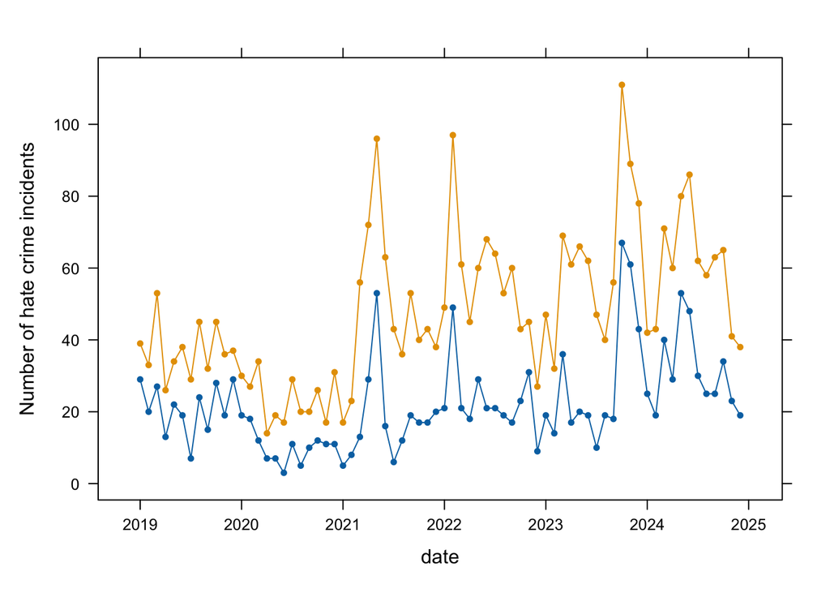

```r
AJ = subset(H3, antijewish==T & date<2025.4)
AJ$AntiJewish=AJ$count
AJ$AllOther = AJ$total - AJ$count
AJ$Total = AJ$total
xyplot(AntiJewish + Total ~date, type="b", data=AJ, pch=20,
       ylab="Number of hate crime incidents")
```

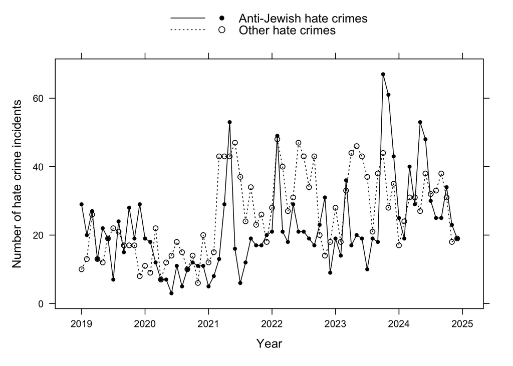

```r
xyplot(AntiJewish + AllOther ~date, type="b", data=AJ, pch=c(20, 1), lty=c(1,3), col="black",
       ylab="Number of hate crime incidents", xlab="Year", key=list(space="top",
         lines=list(pch=c(20, 1), lty=c(1,3), lwd=1), points=list(pch=c(20, 1)),
         text=list(c("Anti-Jewish hate crimes","Other hate crimes"))
))
```

```r
perc.antijewish=with(subset(H3, antijewish==T& date<2025), 100*count/total)
favstats(~perc.antijewish)
```

```
##       min       Q1   median       Q3      max     mean      sd  n missing
##  13.95349 34.69351 46.51442 53.89833 78.37838 45.18539 14.0992 72       0
```

```r
count(perc.antijewish>=50)
```

```
## n_TRUE
##     31
```

```r
length(perc.antijewish)
```

```
## [1] 72
```

```r
perc.antijewish[58:72]
```

```
##  [1] 60.36036 68.53933 55.12821 59.52381 44.18605 56.33803 48.33333 66.25000
##  [9] 55.81395 48.38710 43.10345 39.68254 52.30769 56.09756 50.00000
```

```r
length(perc.antijewish[58:72])
```

```
## [1] 15
```

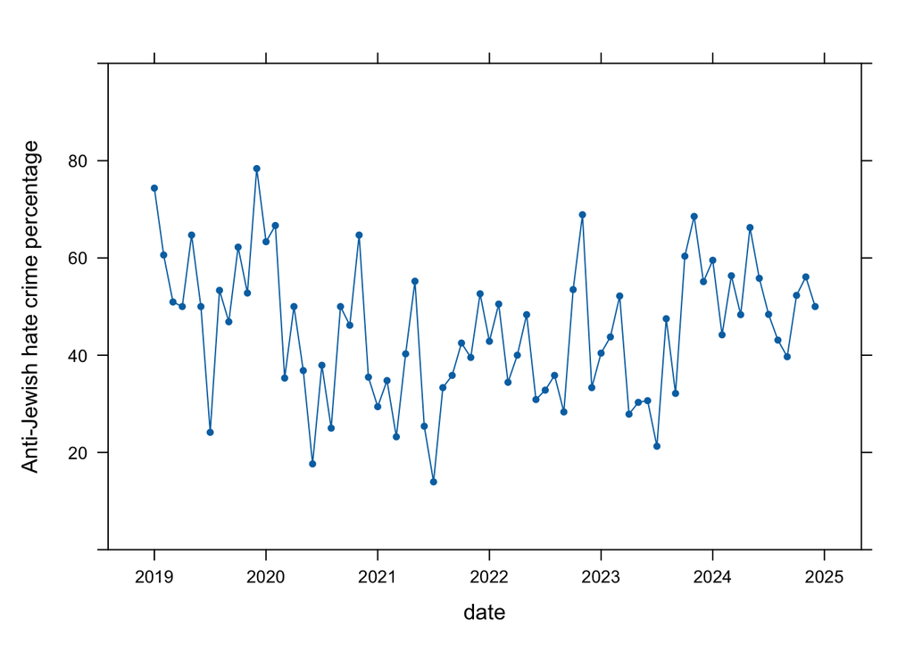

```r
xyplot(100*count/total ~date, type="b", subset=(antijewish==T & date<2025), data=H3,
       ylab="Anti-Jewish hate crime percentage", pch=20, ylim=c(0,100))
```

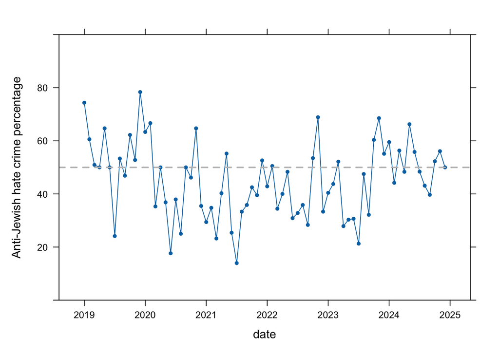

```r
ladd(panel.abline(h=50, lty=2, lwd=2, col="grey"))
```

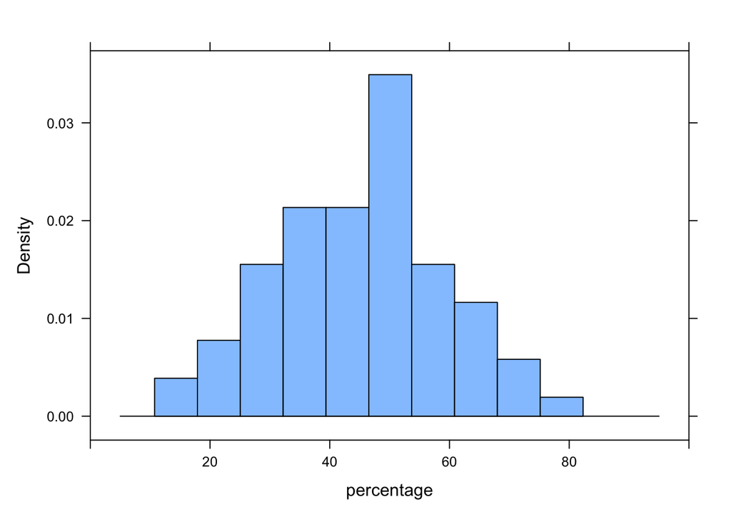

```r
H3date=subset(H3, date<2025)
H3date$percentage = 100*H3date$count/H3date$total
histogram(~percentage, data=subset(H3date, antijewish==T), xlim=c(0,100), nint=10)
```

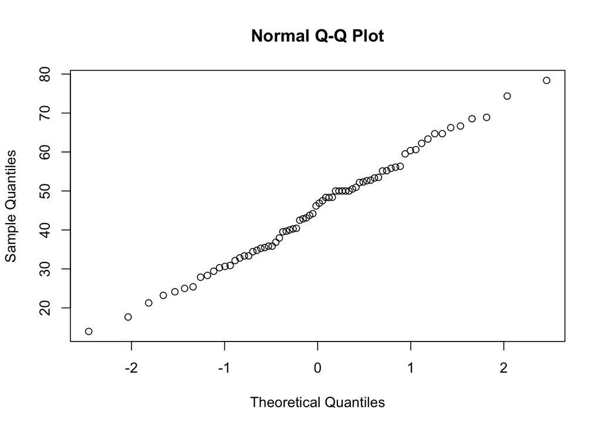

```r
qqnorm(subset(H3date, antijewish==T)$percentage)
abline(a=0, b=1)
```

```r
shapiro.test(subset(H3date, antijewish==T)$percentage)
```

```
##
##  Shapiro-Wilk normality test
##
## data:  subset(H3date, antijewish == T)$percentage
## W = 0.99131, p-value = 0.9052
```

```r
favstats(~percentage, data=subset(H3date, antijewish==T))
```

```
##       min       Q1   median       Q3      max     mean      sd  n missing
##  13.95349 34.69351 46.51442 53.89833 78.37838 45.18539 14.0992 72       0
```

```r
c(45.3, 45.3-14.4, 45.3+14.4)
```

```
## [1] 45.3 30.9 59.7
```

```r
c(45.3, 45.3-14.4*2, 45.3+14.4*2)
```

```
## [1] 45.3 16.5 74.1
```

Previous: In each month, anti-Jewish hate crimes comprise between 14–78% of all hate crimes. At median, 43% of hate crimes are anti-Jewish, with an interquartile range between 33% and 53%. Jews comprise 16% percent of the NYC population.

New: In each month, anti-Jewish hate crimes comprise between 14–78% of all hate crimes. At median, 46% of hate crimes are anti-Jewish, with an interquartile range between 34% and 53%. Jews comprise 16% percent of the NYC population.

Source: Saxe, Leonard; Parmer, Daniel; Tighe, Elizabeth; Magidin de Kramer, Raquel (March 2021). “American Jewish Population Estimates Summary & Highlights” (PDF). Cohen Center for Modern Jewish Studies Steinhardt Social Research Institute. American Jewish Population Project. p. 9. Retrieved February 4, 2024.